# Homework 2

Alessandro Quattrociocchi - 1609286

### Part 1

##### a) Illustrate the characteristics of the statistical model for dealing with the Dugong’s data. Lengths (Yi) and ages (xi) of 27 dugongs (see cows) captured off the coast of Queensland have been recorded and the following (non linear) regression model is considered in Carlin and Gelfand (1991).

This, presented below, is a nonlinear model based on data about the height and age of dugongs. The number of measurements is 27 and the data are modeled as a non-linear growth model.

$Y_i \sim \mathcal{N(\mu_i,\tau)}$ where $\mu_i = f(x_i)= \alpha -\beta \gamma^{x_i}$, with $i= 1,...,27$

##### b) Derive the corresponding likelihood function

Likelihood function:
$$\begin{align}
L(\alpha,\beta,\gamma,\tau|y,x) = \prod_{i=1}^n \frac{1}{\Big(2\pi \tau^2\Big)^{\frac{1}{2}}} exp\bigg\{-\frac{(y_i-\mu_i)^2}{2\tau^2} \bigg\}\mathbb{1}_{(1, \infty)}(\alpha)\mathbb{1}_{(1, \infty)}(\beta)\mathbb{1}_{(0,1)}(\gamma)\mathbb{1}_{(0, \infty)}(\tau^2) =
\end{align}$$

$$\begin{align}
= \frac{1}{\Big(2\pi \tau^2\Big)^{\frac{n}{2}}} exp\bigg\{-\frac{\sum_{i=1}^{n}(y_i-\mu_i)^2}{2\tau^2} \bigg\}
\mathbb{1}_{(1, \infty)}(\alpha)\mathbb{1}_{(1, \infty)}(\beta)\mathbb{1}_{(0,1)}(\gamma)\mathbb{1}_{(0, \infty)}(\tau^2)=
\end{align}$$

$$\begin{align}
= \frac{1}{\Big(2\pi \tau^2\Big)^{\frac{n}{2}}} exp\bigg\{-\frac{\sum(y_i-\alpha+\beta \gamma^{x_i})^2}{2\tau^2} \bigg\}
\end{align}$$

##### c) Write down the expression of the joint prior distribution of the parameters at stake and illustrate your suitable choice for the hyperparameters.

We can write the joint as the product of the following blocks:

$$\begin{align}
\pi(\alpha) = \frac{1}{\sqrt(2\pi\sigma_\alpha^2)} e^{-\frac{\alpha}{2\sigma_\alpha^2}}\mathbb{1}_{(1, \infty)}(\alpha) \longrightarrow e^{-\frac{\alpha}{2\sigma_\alpha^2}}\mathbb{1}_{(1, \infty)}(\alpha)
\end{align}$$

$$\begin{align}
\pi(\beta) = \frac{1}{\sqrt(2\pi\sigma_\beta^2)} e^{-\frac{\beta}{2\sigma_\beta^2}}\mathbb{1}_{(1, \infty)}(\beta) \longrightarrow e^{-\frac{\beta}{2\sigma_\beta^2}}\mathbb{1}_{(1, \infty)}(\beta)
\end{align}$$

$$\begin{align}
\pi(\gamma) = Unif(0,1)(\gamma)
\end{align}$$

$$\begin{align}
\pi(\tau^2) = InvGamma(a,b) = \frac{b^a}{\Gamma(a)}\tau^{-2(a+1)} e^{-\frac{b}{\tau^2}}\mathbb{1}_{(1, \infty)}(\gamma)\longrightarrow
\tau^{-2(a+1)}e^{-\frac{b}{\tau^2}}\mathbb{1}_{(0, \infty)}
\end{align}$$

$$\begin{align}
\boxed{\pi(\theta) = \pi(\alpha) \cdot \pi(\beta) \cdot \pi(\gamma) \cdot \pi(\tau^2) = e^{-\frac{\alpha}{2\sigma_\alpha^2}} \cdot e^{-\frac{\beta}{2\sigma_\beta^2}} \cdot \mathbb{1}_{(0, 1)}(\gamma) \cdot \tau^{-2(a+1)}e^{-\frac{b}{\tau^2}}}
\end{align}$$

##### d) Derive the functional form (up to proportionality constants) of all full-conditionals

### $\alpha$

$$\begin{align}
\pi(\alpha | \beta, \gamma,\tau^2,x,y) = \frac{1}{(2\pi\tau^2)^{\frac{n}{2}}} exp\{- \frac{1}{2\tau^2} \sum_{i=1}^{n} (y_i-\mu_i)^2 \} \frac{1}{\sqrt{2\pi\sigma_{\alpha}^2}} exp\{ - \frac{\alpha^2}{2\sigma_{\alpha}^2} \}\mathbb{1}_{(1, \infty)}(\alpha)
\end{align}$$

$$\begin{align}
= \frac{1}{(2\pi\tau^2)^{\frac{n}{2}}} exp\{ - \frac{1}{2\tau^2} \sum_{i=1}^{n} (y_i -\alpha + \beta\gamma^{x_i})^2 \} \frac{1}{\sqrt{2\pi\sigma_{\alpha}^2}} exp\{- \frac{\alpha^2}{2\sigma_{\alpha}^2} \} \mathbb{1}_{(1, \infty)}(\alpha)
\end{align}$$

$$\begin{align}
\propto exp\{ - \frac{1}{2\tau^2} \sum_{i=1}^{n} (y_i -\alpha + \beta\gamma^{x_i})^2 \} exp\{- \frac{\alpha^2}{2\sigma_{\alpha}^2}\} \mathbb{1}_{(1, \infty)}(\alpha)
\end{align}$$

$$\begin{align}
\propto exp\{ - \frac{\alpha^2}{2\sigma_{\alpha}^2} - \frac{\sum_{i=1}^{n} (\alpha^2 - 2\alpha y_i -2\alpha\beta\gamma^{x_i})}{2\tau^2}\} \mathbb{1}_{(1, \infty)}(\alpha)
\end{align}$$

$$\begin{align}
\propto exp\{- \frac{\alpha^2}{2} \frac{\tau^2 + n\sigma_{\alpha}^2}{\sigma_{\alpha}^2 \tau^2} + \alpha \frac{\sigma_{\alpha}^2 \sum_{i=1}^{n}(y_i+\beta\gamma^{x_i}) }{ \sigma_{\alpha}^2 \tau^2} \} \mathbb{1}_{(1, \infty)}(\alpha)
\end{align}$$

$$\begin{align}
\boxed{\pi(\alpha | \beta, \gamma,\tau^2,x,y) \sim \mathcal{N} (\frac{\sigma_{\alpha}^2 \sum_{i=1}^{n}(y_i+\beta\gamma^{x_i})}{\tau^2 + n\sigma_{\alpha}^2}, \frac{\sigma_{\alpha}^2 \tau^2}{\tau^2 + n\sigma_{\alpha}^2} )\mathbb{1}_{(1, \infty)}}
\end{align}$$

### $\beta$

$$\begin{align}
\pi(\beta | \alpha, \gamma,\tau^2,x,y) = \frac{1}{(2\pi\tau^2)^{\frac{n}{2}}} exp\{- \frac{1}{2\tau^2} \sum_{i=1}^{n} (yi-\mu_i)^2 \} \frac{1}{\sqrt{2\pi\sigma_{\beta}^2}} exp\{ - \frac{\beta^2}{2\sigma_{\beta}^2} \}\mathbb{1}_{(1, \infty)}(\beta)
\end{align}$$

$$\begin{align}
= \frac{1}{(2\pi\tau^2)^{\frac{n}{2}}} exp\{ - \frac{1}{2\tau^2} \sum_{i=1}^{n} (y_i -\alpha + \beta\gamma^{x_i})^2 \} \frac{1}{\sqrt{2\pi\sigma_{\beta}^2}} exp\{- \frac{\beta^2}{2\sigma_{\beta}^2} \} \mathbb{1}_{(1, \infty)}(\beta)
\end{align}$$

$$\begin{align}
\propto exp\{ - \frac{1}{2\tau^2} \sum_{i=1}^{n} (y_i -\alpha + \beta\gamma^{x_i})^2 \} exp\{- \frac{\beta^2}{2\sigma_{\beta}^2} \mathbb{1}_{(1, \infty)}(\beta) \}
\end{align}$$

$$\begin{align}
\propto exp\{ - \frac{\beta^2}{2\sigma_{\beta}^2} - \frac{\sum_{i=1}^{n} (\beta^{2}\gamma^{2x_i} -2\beta y_{i}\gamma^{x_i} -2\alpha\beta\gamma^{x_i})}{2\tau^2}\} \mathbb{1}_{(1, \infty)}(\beta)
\end{align}$$

$$\begin{align}
\propto exp\{- \frac{\beta^2}{2} \frac{\tau^2 + \sigma_{\beta}^2 \sum_{i=1}^{n} \gamma^{2x_i}}{\sigma_{\beta}^2 \tau^2} + \beta \frac{\sigma_{\beta}^2 \sum_{i = 1}^{n} \gamma^{x_i}(\alpha - y_i) }{\sigma_{\beta}^2 \tau^2} \} \mathbb{1}_{(1, \infty)}(\beta)
\end{align}$$

$$\begin{align}
\boxed{\pi(\beta | \alpha, \gamma,\tau^2,x,y) \sim \mathcal{N}{(1,\infty)} (\frac{\sigma_{\beta}^2 \sum_{i = 1}^{n} \gamma^{x_i}(\alpha - y_i)}{\tau^2 + \sigma_{\beta}^2 \sum_{i = 1}^{n} \gamma^{2x_i}} , \frac{\sigma_{\beta}^2 \tau^2}{\tau^2 + \sigma_{\beta}^2 \sum_{i = 1}^{n} \gamma^{2x_i}} )\mathbb{1}_{(1, \infty)}}
\end{align}$$

### $\gamma$

$$\begin{align}
\pi(\gamma | \alpha, \beta,\tau^2,x,y) = \frac{1}{(2\pi\tau^2)^{\frac{n}{2}}} exp\{-\frac{1}{2\tau^2}\sum_{i=1}^{n} (y_i - \mu_i)^2\} \mathbb{1}_{(0, 1)}(\gamma)=
\end{align}$$

$$\begin{align}
= \frac{1}{(2\pi\tau^2)^{\frac{n}{2}}} exp\{-\frac{1}{2\tau^2}\sum_{i=1}^{n} (y_i - \alpha + \beta\gamma^{x_i})^2\} \mathbb{1}_{[0, 1]}(\gamma)
\end{align}$$

$$\begin{align}
\boxed{\pi(\gamma | \alpha, \beta,\tau^2,x,y) \propto exp\{-\frac{1}{2\tau^2}\sum_{i=1}^{n} (y_i - \alpha + \beta\gamma^{x_i})^2\} \mathbb{1}_{(0, 1)}(\gamma)}
\end{align}$$

### $\tau^2$

$$\begin{align}
\pi(\tau^2 | \alpha, \beta,\gamma,x,y) = \frac{1}{\tau^{2(\frac{n}{2}) } \tau^{2(\alpha +1)} } exp\{-\frac{\frac{1}{2} \sum_{i=1}^{n}(y_i -\alpha + \beta\gamma^{x_i})^2 -b }{ \tau^2}\}\mathbb{1}_{(0, 1)}(\tau^2)
\end{align}$$

$$\begin{align}
\frac{1}{\tau^{2(\frac{n}{2} + \alpha +1)}} exp\{- \frac{b + \frac{1}{2} \sum_{i=1}^{n}(y_i -\alpha + \beta\gamma^{x_i})^2}{\tau^2}\}\mathbb{1}_{[0, 1]}(\tau^2)
\end{align}$$

$$\begin{align}
\boxed{\pi(\tau^2 | \alpha, \beta,\gamma,x,y) \sim IG_{(0, \infty)}(\alpha + \frac{n}{2}, b + \frac{1}{2} \sum_{i=1}^{n}(y_i -\alpha + \beta\gamma^{x_i})^2)}
\end{align}$$

###### Suitable choice for the hyperparameters.

For the choice of hyper-parameters I did several tests and noticed that even very different values did not change much the results. In some cases, for very low values of $\sigma_a$ and $\sigma_b$ lead a slower convergence in the next points. The values are the following inserted in the code below.

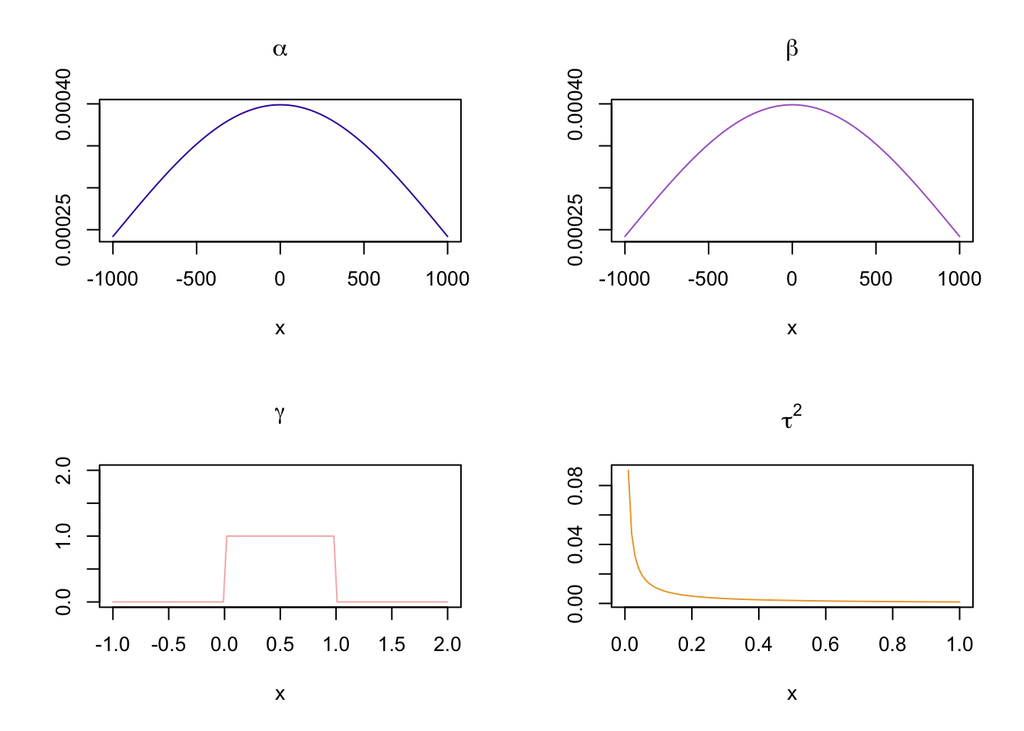

```r
sigma_squared_a= sigma_squared_b  = 1000
a=b=1/sigma_squared_a
par(mfrow=c(2,2))
curve(dnorm(x,0,sigma_squared_a),from=-sigma_squared_a,to=sigma_squared_a, main= expression(alpha), ylab="",col="#3b14a7")
curve(dnorm(x,0,sigma_squared_b),from=-sigma_squared_a,to=sigma_squared_b, main= expression(beta), ylab="",col= "#ac66cc")
curve(dunif(x,0,1),from=-1,to=2, ylim=c(0,2), ylab="", main= expression(gamma),col = "#f6b8b8")
curve(dinvgamma(x,a,b),ylab="",from = 0, to= 1, main=expression(tau^2),col = "#eba83a")
```

##### e) Which distribution can you recognize within standard parametric families so that direct simulation from full conditional can be easily implemented?

The parameters $\alpha$, $\beta$ and $\tau^2$ belong to a standard parametric families like Normal and Inverse-Gamma. The parameter $\gamma$, does not belongs to a standard parametric family, for this reason i implemented Metropolis-Hastings algorithm.

##### f) Using a suitable Metropolis-within-Gibbs algorithm simulate a Markov chain (T = 10000) to approximate the posterior distribution for the above model

```r
alpha[1] = 2
beta[1] = 2
gamma[1] = 0.5
tau_square[1] = 0.1


# full conditional gamma
full_cond_gamma = function(x,y,gamma, alpha, beta, tau_square) {
  return(exp(-1/(2*tau_square)*sum((y-alpha+beta*gamma^x)^2)))
}

metropolis.gibbs <- function(x, y,alpha, beta, gamma,tau_square,sigma_squared_a,sigma_squared_b,a,b,n,iterations) {
for(t in 1:iterations) {
  # updating the t+1 th term of the alpha Markov chain
  alpha[t+1] = rnorm(1,(sigma_squared_a*sum(y+beta[t]*gamma[t]^x))/(n*sigma_squared_a+tau_square[t]),
                     sqrt((tau_square[t]*sigma_squared_a)/(n*sigma_squared_a + tau_square[t])))
  # updating the t+1 th term of the alpha Markov chain
  beta[t+1] = rnorm(1,(sigma_squared_b*sum((alpha[t+1]-y)*gamma[t]^x)) /
                      (sigma_squared_b*sum(gamma[t]^(2*x))+tau_square[t]),
                    sqrt((tau_square[t]*sigma_squared_b)/(sigma_squared_b*sum(gamma[t]^(2*x))+tau_square[t])))
#proposal is a float value taken from a uniform distribution.
  proposal = runif(1,0,1)
#computing the probability given by the full conditional for the parameter gamma accordigly to the proposal generated.
  prob = full_cond_gamma(x,y,proposal, alpha[t+1], beta[t+1], tau_square[t]) /
    full_cond_gamma(x,y,gamma[t], alpha[t+1], beta[t+1], tau_square[t])
#If the posterior probability is greater than the new value theta, the ratio of the probability
#will be greater than 1 and we will always accept the new value of theta.
#If the posterior probability is greater for the posterior value of theta we will not necessarily discard that value.
  gamma[t+1] = ifelse(runif(1,0,1)<=prob, proposal, gamma[t])
  tau_square[t+1] = rinvgamma(1, n/2 + a,
                              b+1/2*sum((y-alpha[t+1]+beta[t+1]*(gamma[t+1]^x))^2))
}

coll <- list ("alpha" = alpha,"beta" = beta,"gamma" = gamma, "tau_square" = tau_square)
return (coll)
}
```

```r
MH = metropolis.gibbs(x=age, y=length.d,alpha=alpha, beta=beta, gamma=gamma,tau_square=tau_square,sigma_squared_a=1000,sigma_squared_b=1000,a=0.001,b=0.001,n=27,iterations=10000)

alpha = MH$alpha
beta = MH$beta
gamma = MH$gamma
tau_square = MH$tau_square

head(cbind(alpha,beta,gamma,tau_square),10)
```

```
##          alpha     beta gamma tau_square
##  [1,] 2.000000 2.000000   0.5 0.10000000
##  [2,] 2.416427 1.806716   0.5 0.01773332
##  [3,] 2.512316 1.792080   0.5 0.01479683
##  [4,] 2.460897 1.820485   0.5 0.03139337
##  [5,] 2.511735 1.724224   0.5 0.01809699
##  [6,] 2.402435 1.539494   0.5 0.02973206
##  [7,] 2.485415 1.814080   0.5 0.01826653
##  [8,] 2.437459 1.635838   0.5 0.02038419
##  [9,] 2.515340 1.585770   0.5 0.02784156
## [10,] 2.440265 1.717756   0.5 0.02710155
```

##### g) Show the 4 univariate trace-plots of the simulations of each parameter

We can see how after a certain transient the values of the variables stabilize around a certain average value.

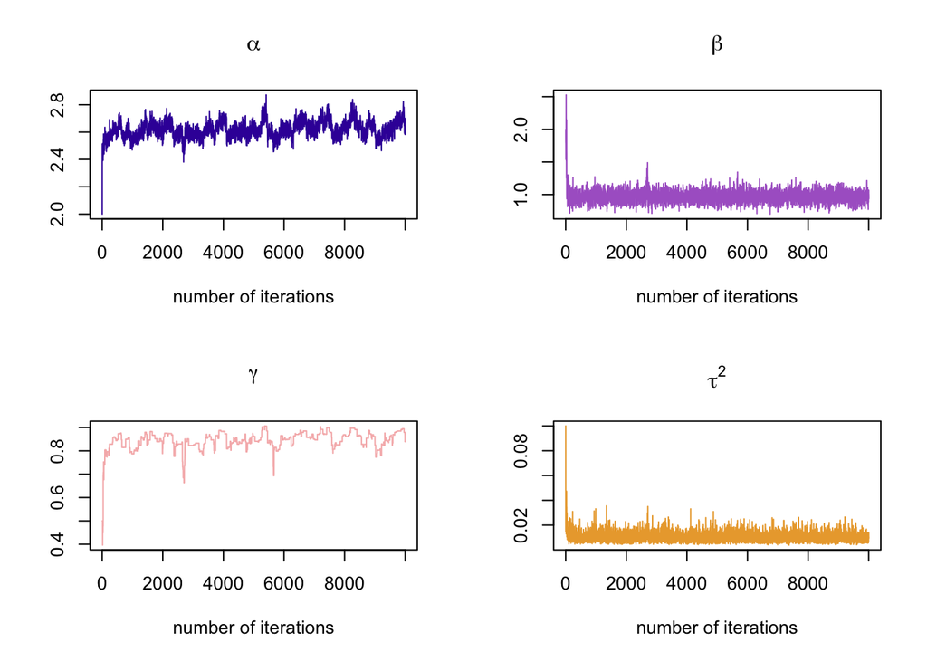

```r
par(mfrow=c(2,2))
plot(alpha,xlab ="number of iterations",main= expression(alpha),ylab = " ",type="l",col="#3b14a7")
plot(beta,xlab ="number of iterations", main= expression(beta),ylab = " ",type="l", col= "#ac66cc")
plot(gamma,xlab ="number of iterations", main= expression(gamma),ylab = " ",type="l", col = "#f6b8b8")
plot(tau_square,xlab ="number of iterations", main= expression(tau^2),ylab = " ",type="l", col = "#eba83a")
```

##### h) Evaluate graphically the behaviour of the empirical averages I with growing t = 1, …,T.

The empirical averages calculated in this point, converges to the maean value of the Markov chain, as the number of iterations increases.

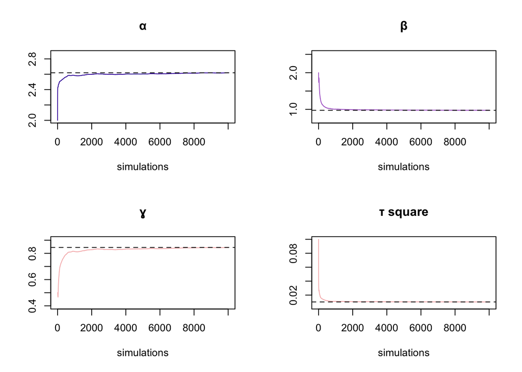

```r
plotting.trace <- function(parameter,name,color){
plot(cumsum(parameter)/(1:length(parameter)), type="l",ylim = c(min(parameter), max(parameter)), ylab=" ",
      xlab="simulations",col=color, main = paste0(name))
abline(h=mean(parameter), col="grey1",lty=2)
}

par(mfrow=c(2,2))
plotting.trace(alpha,"\u03B1","#3b14a7")
plotting.trace(beta,"\u03B2","#ac66cc")
plotting.trace(gamma,"\u0263","#f6b8b8")
plotting.trace(tau_square,"\u03C4 square","#f6b8b8")
```

##### i) Provide estimates for each parameter together with the approximation error and explain how you have evaluated such error

approximation error for each parameter

```r
approx_error <- function(parameter) {
  return(var(parameter)/length(parameter))}

rbind(
alpha_err <- approx_error(alpha),
beta_err <- approx_error(beta),
gamma_err <- approx_error(gamma),
tau_err <- approx_error(tau_square))
```

```
##              [,1]
## [1,] 3.377462e-07
## [2,] 8.242178e-07
## [3,] 1.526304e-07
## [4,] 1.167281e-09
```

##### l) Which parameter has the largest posterior uncertainty? How did you measure it? coefficient of variation for each parameter

```r
parameter_var <- function(parameter) {
  return(sd(parameter)/abs(mean(parameter)))}

cat("alpha:", parameter_var(alpha),
    "beta:", parameter_var(beta),
    "gamma:", parameter_var(gamma),
    "tau_square:", parameter_var(tau_square))
```

```
## alpha: 0.02219268 beta: 0.09321667 gamma: 0.04625642 tau_square: 0.3369454
```

The parameter $\tau$ is the one with the largest posterior uncertainty.

##### m) Which couple of parameters has the largest correlation (in absolute value)? coefficient of variation for each parameter

```r
A = rbind(cbind(cor(MH$alpha,MH$alpha),cor(MH$alpha,MH$beta),cor(MH$alpha,MH$gamma),cor(MH$alpha,MH$tau_square)),
cbind(cor(MH$beta,MH$alpha),cor(MH$beta,MH$beta),cor(MH$beta,MH$gamma),cor(MH$beta,MH$tau_square)),
cbind(cor(MH$gamma,MH$alpha),cor(MH$gamma,MH$beta),cor(MH$gamma,MH$gamma),cor(MH$gamma,MH$tau_square)),
cbind(cor(MH$tau_square,MH$alpha),cor(MH$tau_square,MH$beta),cor(MH$tau_square,MH$gamma),cor(MH$tau_square,MH$tau_square)))
A
```

```
##             [,1]        [,2]       [,3]       [,4]
## [1,]  1.00000000  0.09479284  0.7789289 -0.2095655
## [2,]  0.09479284  1.00000000 -0.4247732  0.1795384
## [3,]  0.77892891 -0.42477325  1.0000000 -0.3184767
## [4,] -0.20956546  0.17953841 -0.3184767  1.0000000
```

$\alpha$ and $\gamma$ are the two vector with the higest absolute value of correlation.

##### n) Use the Markov chain to approximate the posterior predictive distribution of the length of a dugong with age of 20 years.

```r
dugong_at_20=rep(NA, iterations)
for(i in 1:iterations){dugong_at_20[i]=rnorm(1, alpha[i] - beta[i]*gamma[i]^20, sqrt(tau_square[i]))}
head(dugong_at_20,5)
```

```
## [1] 2.015655 2.476508 2.525843 2.467828 2.329342
```

##### o) Provide the prediction of a different dugong with age 30

```r
dugong_at_30=rep(NA, iterations)
for(i in 1:iterations){dugong_at_30[i]=rnorm(1, alpha[i] - beta[i]*gamma[i]^30, sqrt(tau_square[i]))}
head(dugong_at_30,5)
```

```
## [1] 1.921122 2.436038 2.404402 2.552805 2.469294
```

##### p) Which prediction is less precise?

In order to states which one is more precise than the other, as we did before, we can compute the precision as the reciprocal variance for the dugongs at age 20 and at age 30. After that is the ratio is greater than 1 we can assume that the precision of length is more precise at 20 than 30.

```r
if (var(dugong_at_30)/var(dugong_at_20)>1){
  print("Prediction at 20 more precise than at 30")}
```

```
## [1] "Prediction at 20 more precise than at 30"
```

```r
if(var(dugong_at_30)/var(dugong_at_20)<1){
  print("Prediction at 30 more precise than at 20")
}
```

### Part 2

##### a) Starting at time t = 0 in the state X0 = 1 simulate the Markov chain with distribution assigned as above for t = 1000 consecutive times

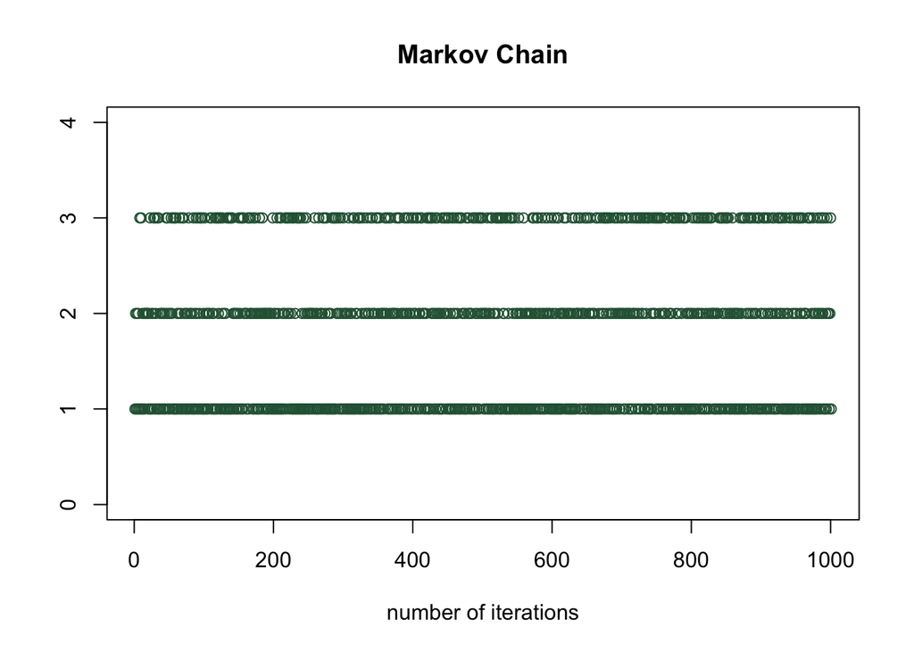

```r
set.seed(444)
script_S=c(1,2,3)
tpm<-rbind(c(0,1/2,1/2),c(5/8,1/8,1/4),c(2/3,1/3,0))
#tpm is transition probability matrix

x1<-1
mu <- c(1,0,0)
nsample<-1000
chain<-rep(NA,nsample+1)
chain[1]<-x1
t <- 1
for(t in 1:nsample){
  chain[t+1]<-sample(script_S,size=1,prob=tpm[chain[t],])
}
#chain
plot(chain,ylim=c(0,4), col="#2a6041", main = "Markov Chain", ylab= "", xlab= "number of iterations")
```

##### b) compute the empirical relative frequency of the two states in your simulation

```r
x1<-2
mu <- c(1,0,0)
nsample<-1000
chain_state2<-rep(NA,nsample+1)
chain_state2[1]<-x1
t <- 1
for(t in 1:nsample){
  chain_state2[t+1]<-sample(script_S,size=1,prob=tpm[chain[t],])
}
cat("State 1: ",prop.table(table(chain)),"\nState 2: ",prop.table(table(chain_state2)))
```

```
## State 1:  0.3856144 0.3416583 0.2727273
## State 2:  0.3946054 0.3136863 0.2917083
```

##### c) Repeat the simulation for 500 times and record only the final state at time t = 1000 for each of the 500 simulated chains.Compute the relative frequency of the 500 final states. What distribution are you approximating in this way? Try to formalize the difference between this point and the previous point.

```r
chain.final.state <- function(n,nsample,x0){

t_chain=rep(NA, n)
for (i in 1:n){

  chain=rep(NA,nsample+1)
  chain[1]=x0
  for(t in 1:nsample){
    chain[t+1]=sample(script_S,size=1,prob=tpm[chain[t],])
  }
  t_chain[i]=tail(chain,1)
}
return(t_chain)
}
chain.fin_x01 = chain.final.state(n=500,nsample=1000,x0=1)
rbind(prop.table(table(chain)),prop.table(table(chain.fin_x01)))
```

```
##              1         2         3
## [1,] 0.3856144 0.3416583 0.2727273
## [2,] 0.4000000 0.3140000 0.2860000
```

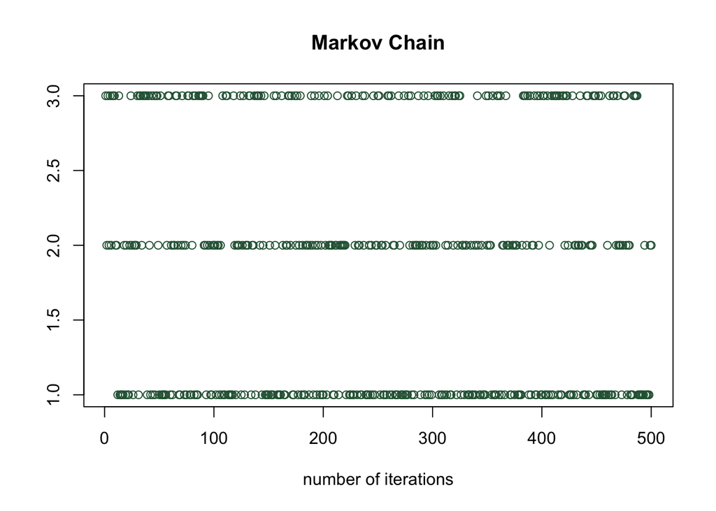

```r
plot(chain.fin_x01,ylim=c(1,3), col="#2a6041", main = "Markov Chain", ylab= "", xlab= "number of iterations")
```

In this case we are, in contrast to the previous point in which we considered the whole Markov chain of the process, we are taking only the last state of 500 different chains. On the other hand, if the process is ergotic, the probability of different states (1,2,3 in this exercise) converges to the same distribution. Also, because we are taking the final values of each of the 500 Markov chains allows us to say that we are still taking a good approximation for our process, because we have already reached the stability stage of the process.

##### d) Compute the theoretical stationary distribution and explain how you have obtained it.

In this case (3 dimensional space), the stationary distribution can be found by solving the following linear system.
$$\begin{align}
\begin{pmatrix}
p_{11} & p_{12}& p_{13}\\
p_{21} &p_{22} &p_{23}\\
p_{131} &p_{32}&p_{33}
\end{pmatrix}
\begin{pmatrix}
\pi_1\\
\pi_2\\
\pi_3
\end{pmatrix}
=
\begin{pmatrix}
\pi_1\\
\pi_2\\
\pi_3
\end{pmatrix}
\end{align}$$

This matrix linear system can be written in a more compact way as following:
$$\begin{align}
P^{T}\pi=\pi \\
(P^{T}-\lambda I)\pi = 0
\end{align}$$
Remembering that the only equation in which we are interested on, is the one that satisfy this property:
$$\begin{align}
\pi_1 + \pi_2 + \pi_3 = 1
\end{align}$$

At the end, we can solve the system finding the eigenvectors associated to the corresponding eingvalues.

##### e) Is it well approximated by the simulated empirical relative frequencies computed in (b) and (c)?

```r
tpm.aux = tpm
for (i in 1:1000 ) {tpm.aux = tpm.aux %*% tpm }
cat("Evaluation in point b: ",prop.table(table(chain)),"\nEvaluation in point c:",prop.table(table(chain.fin_x01)),"\nFinal evaluation:",tpm.aux[1,])
```

```
## Evaluation in point b:  0.3856144 0.3416583 0.2727273
## Evaluation in point c: 0.4 0.314 0.286
## Final evaluation: 0.3917526 0.3298969 0.2783505
```

Yes, we can see that the difference is almost very small.

##### f) What happens if we start at t = 0 from state X0 = 2 instead of X0 = 1?

```r
chain.fin_x02 = chain.final.state(n=500,nsample=1000,x0=2)
cat("State 1: ",prop.table(table(chain.fin_x01)),"\nState 2: ",prop.table(table(chain.fin_x02)))
```

```
## State 1:  0.4 0.314 0.286
## State 2:  0.398 0.322 0.28
```

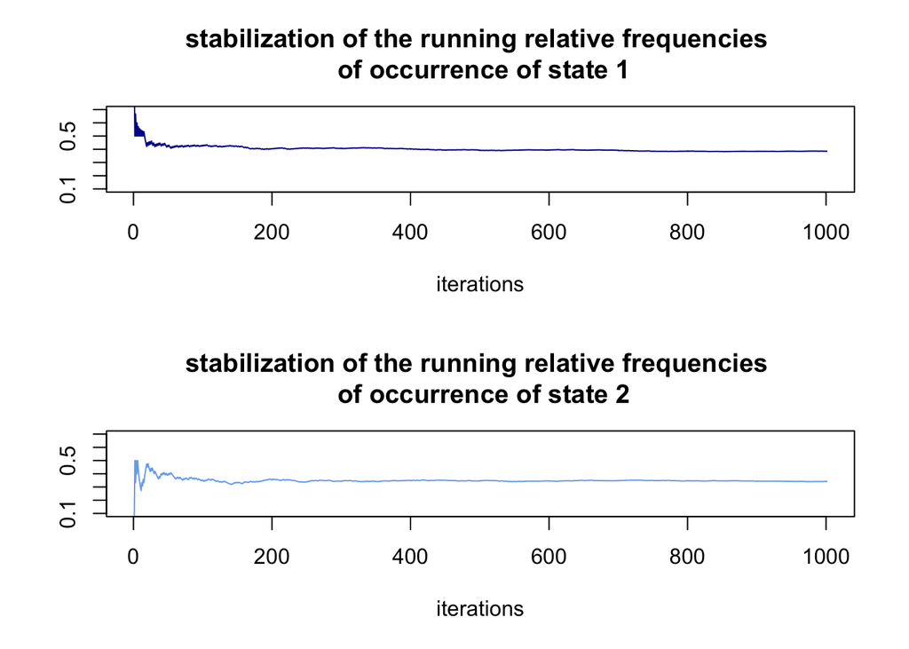

```r
par(mfrow=c(2,1))
plot(1:length(chain),cumsum(chain==1)/(1:length(chain)),type="l",ylim = c(0.1,0.7),xlab = "iterations",ylab = "",main= "stabilization of the running relative frequencies \n of occurrence of state 1", col= "#04009a")
plot(1:length(chain),cumsum(chain==2)/(1:length(chain)),type="l",ylim = c(0.1,0.7),xlab = "iterations",ylab = "",main= "stabilization of the running relative frequencies \n of occurrence of state 2",col= "#77acf1")
```

```r
rbind(tail(cumsum(chain==1)/(1:length(chain)),1),
tail(cumsum(chain==2)/(1:length(chain)),1),
tail(cumsum(chain==3)/(1:length(chain)),1))
```

```
##           [,1]
## [1,] 0.3856144
## [2,] 0.3416583
## [3,] 0.2727273
```